# Regular Expressions 3

Ahmed Meky

April 17, 2022

#### Github Link: https://github.com/ahmedmmeky/STAT184-Activities/blob/main/regex3.nb.html

#### Load Packages & Data & Preview Initial Data

```r
library(tidyverse)
library(dplyr)
library(stringr)
library(tidyr)
library(ggplot2)
library(NLP)
TournamentStats <- read.csv("Data_RegEx3.csv", header = T)
tail(TournamentStats)
```

|  | tourney_id | tourney_name | winner_ioc | winner_age | score | minutes |
| --- | --- | --- | --- | --- | --- | --- |
| 9107 | 2019-560 | Us Open | BUL | 28.27926 | 3-6 6-4 3-6 6-4 6-2 | 192 |
| 9108 | 2019-560 | Us Open | ITA | 23.37029 | 3-6 6-3 6-2 3-6 7-6(5) | 237 |
| 9109 | 2019-560 | Us Open | ESP | 33.22930 | 6-4 7-5 6-2 | 167 |
| 9110 | 2019-560 | Us Open | RUS | 23.53730 | 7-6(5) 6-4 6-3 | 158 |
| 9111 | 2019-560 | Us Open | ESP | 33.22930 | 7-6(6) 6-4 6-1 | 155 |
| 9112 | 2019-560 | Us Open | ESP | 33.22930 | 7-5 6-3 5-7 4-6 6-4 | 290 |

#### Creation of New Year Variable Based on First Four Digits of tourney_id

```r
StatsWYear <- TournamentStats %>% mutate(year = str_sub(tourney_id, 1,4));
tail(StatsWYear)
```

|  | tourney_id | tourney_name | winner_ioc | winner_age | score | minutes | year |
| --- | --- | --- | --- | --- | --- | --- | --- |
| 9107 | 2019-560 | Us Open | BUL | 28.27926 | 3-6 6-4 3-6 6-4 6-2 | 192 | 2019 |
| 9108 | 2019-560 | Us Open | ITA | 23.37029 | 3-6 6-3 6-2 3-6 7-6(5) | 237 | 2019 |
| 9109 | 2019-560 | Us Open | ESP | 33.22930 | 6-4 7-5 6-2 | 167 | 2019 |
| 9110 | 2019-560 | Us Open | RUS | 23.53730 | 7-6(5) 6-4 6-3 | 158 | 2019 |
| 9111 | 2019-560 | Us Open | ESP | 33.22930 | 7-6(6) 6-4 6-1 | 155 | 2019 |
| 9112 | 2019-560 | Us Open | ESP | 33.22930 | 7-5 6-3 5-7 4-6 6-4 | 290 | 2019 |

#### Creation of Sets based on Score Variables

[output not shown]

#### Creation of setsplayed Variable

```r
SetsPlayed <- FinalSets %>% mutate(setsplayed = as.character((rowSums(!is.na(FinalSets[8:12])))))
tail(SetsPlayed)
```

| tourney_id | tourney_name | winner_ioc | winner_age | score | minutes | year | Set.1 | Set.2 | Set.3 | Set.4 | Set.5 | setsplayed |
| --- | --- | --- | --- | --- | --- | --- | --- | --- | --- | --- | --- | --- |
| 2019-560 | Us Open | BUL | 28.27926 | 3-6 6-4 3-6 6-4 6-2 | 192 | 2019 | 3-6 | 6-4 | 3-6 | 6-4 | 6-2 | 5 |
| 2019-560 | Us Open | ITA | 23.37029 | 3-6 6-3 6-2 3-6 7-6(5) | 237 | 2019 | 3-6 | 6-3 | 6-2 | 3-6 | 7-6 | 5 |
| 2019-560 | Us Open | ESP | 33.22930 | 6-4 7-5 6-2 | 167 | 2019 | 6-4 | 7-5 | 6-2 | NA | NA | 3 |
| 2019-560 | Us Open | RUS | 23.53730 | 7-6(5) 6-4 6-3 | 158 | 2019 | 7-6 | 6-4 | 6-3 | NA | NA | 3 |
| 2019-560 | Us Open | ESP | 33.22930 | 7-6(6) 6-4 6-1 | 155 | 2019 | 7-6 | 6-4 | 6-1 | NA | NA | 3 |
| 2019-560 | Us Open | ESP | 33.22930 | 7-5 6-3 5-7 4-6 6-4 | 290 | 2019 | 7-5 | 6-3 | 5-7 | 4-6 | 6-4 | 5 |

#### Creation of Density Plot of Minutes Played by Number of Sets Played

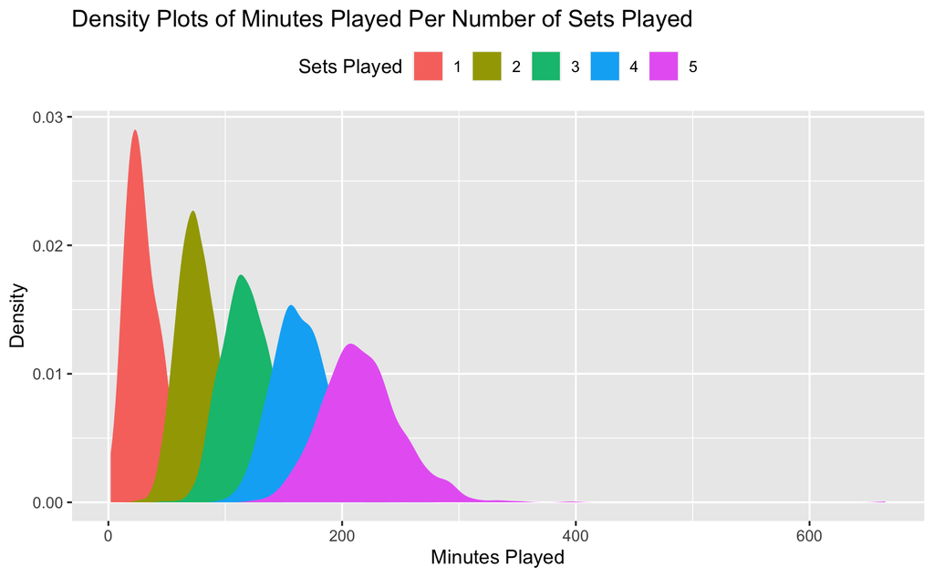

```r
SetsPlayed2 <- SetsPlayed %>% filter(as.integer(setsplayed) > 0)
ggplot(SetsPlayed2, aes(x = minutes, fill = setsplayed)) +
  geom_density( color = NA) +
  theme(legend.position = "top") +
  labs(fill="Sets Played") +
  ylab("Density") +
  xlab("Minutes Played") +
  ggtitle("Density Plots of Minutes Played Per Number of Sets Played")
```

Interpretive Statement for the Above Density Plot: In this density plot we can examine the relationship between sets played and minutes played. Based on the results of this plot, we can see that, generally, an increase of sets results in an increase of minutes played. Also, we see as the number of sets played increases, the level of variation for the minutes played increases.

#### Creation of Boxplot of Winner’s Age by Tournament Name

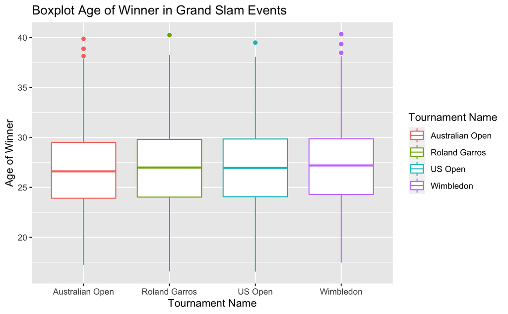

```r
SetsPlayed$tourney_name[SetsPlayed$tourney_name=="Us Open"]<-"US Open"

ggplot(SetsPlayed, aes(x = tourney_name, y = winner_age, color = tourney_name)) +
  geom_boxplot() +
  scale_color_discrete(name = "Tournament Name") +
  ylab("Age of Winner") +
  xlab("Tournament Name") +
  ggtitle("Boxplot Age of Winner in Grand Slam Events")
```